# Lab’s 7 reg logistique

E.ing NEKUI TIEFANG BIEDIANT

2023-03-25

```
        conditions  Reg logistique
```

Nombre d’observation doit être egale aumoins a 10*nbre de paramètres

tester l’hypothèse de linearite sur chaque variable explicative (a ne pas confondre avec le raintest de la rglm)

analyse de surdispersion qui risque de conduire a sous-estimer des erreurs standart des paramètres en evaluant le ratio deviance resi/ddl. si le ratio est trop sup a 1(2), il faudra plustot appliquer la valeur *quasibinomial* au paramètre family de la fonction *glm*

il est aussi a noter qu’en reg logi on interprete pas les coefficients des param mais plutot leurs valeurs exponentielle ils sont appeles odds ratio ou rapport de cote si odds ratio = 1 absence d’effet si odds ratio sup a 1 augmentation du phenomène si odds ratio inf a 1 diminution du phénomène étudié la library(forstmodel) nous permet aussi de deceler la significativité la variables graphiquement  
utiliser la fonction dropl(model, test=“chisq”) la library MASS et le summary de la fonction stepAIC(model) est aussi une alternative

tester la multicolinearité du modèle

significativité du model

inspecter l’influense des var independante

evaluer la qualité du modèle

diagnostic des residus et des valeurs a berrantes

la qualité du modèle se vois à la valeur du passage du Null deviance (nbre de residu non expliqué sans intervention de variable explicative) et du Residual deviance (nbre de residu non expliqué avec intervention de quelques variable explicative)

NB en reg logi les coefficient ne sont pas interpreté

nous pouvons finir avec la matrice de confusion et out les elements qui vont avec

1)linearité entre y et chaque x 2)absence de multicol 3)normalité des residus 4)homocedas 5)indepen des resi 6)significativité du model (auto)

passons a un exemple pratique avecle titanic

1. importer la BD

```r
library(tidyverse)
titanic1=read.csv("/home/nekui-tiefang/dataset/data3/titanic1.csv")
titanic2=read.csv("/home/nekui-tiefang/dataset/data3/titanic2.csv")
```

description de la bd sibsp: nbre frere et soeur + nbre de conjoint parch: nbre enfant ou nbre de parent à bord du navire pour chaque passager. fare: prix payer cabin: numero de la cabine embarked: porte d’embarquement

2. passons au data cleaning

```r
titanic=bind_rows(titanic1,titanic2)
colnames(titanic)
```

```
##  [1] "PassengerId" "Survived"    "Pclass"      "Name"        "Sex"
##  [6] "Age"         "SibSp"       "Parch"       "Ticket"      "Fare"
## [11] "Cabin"       "Embarked"
```

```r
remove(titanic1,titanic2)
```

```r
titanic= titanic[c( "Pclass", "Sex", "Age", "SibSp", "Fare", "Embarked", "Parch", "Survived")]
names(titanic)
```

```
## [1] "Pclass"   "Sex"      "Age"      "SibSp"    "Fare"     "Embarked" "Parch"
## [8] "Survived"
```

```r
summary(titanic)
```

```
##      Pclass          Sex                 Age            SibSp
##  Min.   :1.000   Length:1309        Min.   : 0.17   Min.   :0.0000
##  1st Qu.:2.000   Class :character   1st Qu.:21.00   1st Qu.:0.0000
##  Median :3.000   Mode  :character   Median :28.00   Median :0.0000
##  Mean   :2.295                      Mean   :29.88   Mean   :0.4989
##  3rd Qu.:3.000                      3rd Qu.:39.00   3rd Qu.:1.0000
##  Max.   :3.000                      Max.   :80.00   Max.   :8.0000
##                                     NA's   :263
##       Fare           Embarked             Parch          Survived
##  Min.   :  0.000   Length:1309        Min.   :0.000   Min.   :0.0000
##  1st Qu.:  7.896   Class :character   1st Qu.:0.000   1st Qu.:0.0000
##  Median : 14.454   Mode  :character   Median :0.000   Median :0.0000
##  Mean   : 33.295                      Mean   :0.385   Mean   :0.3838
##  3rd Qu.: 31.275                      3rd Qu.:0.000   3rd Qu.:1.0000
##  Max.   :512.329                      Max.   :9.000   Max.   :1.0000
##  NA's   :1                                            NA's   :418
```

```r
sum(is.na(titanic)) #somme le nbre de valeur manquantes
```

```
## [1] 682
```

```r
colMeans(is.na(titanic)) #pourcentage de valeurs manquante dans chaque colonne
```

```
##       Pclass          Sex          Age        SibSp         Fare     Embarked
## 0.0000000000 0.0000000000 0.2009167303 0.0000000000 0.0007639419 0.0000000000
##        Parch     Survived
## 0.0000000000 0.3193277311
```

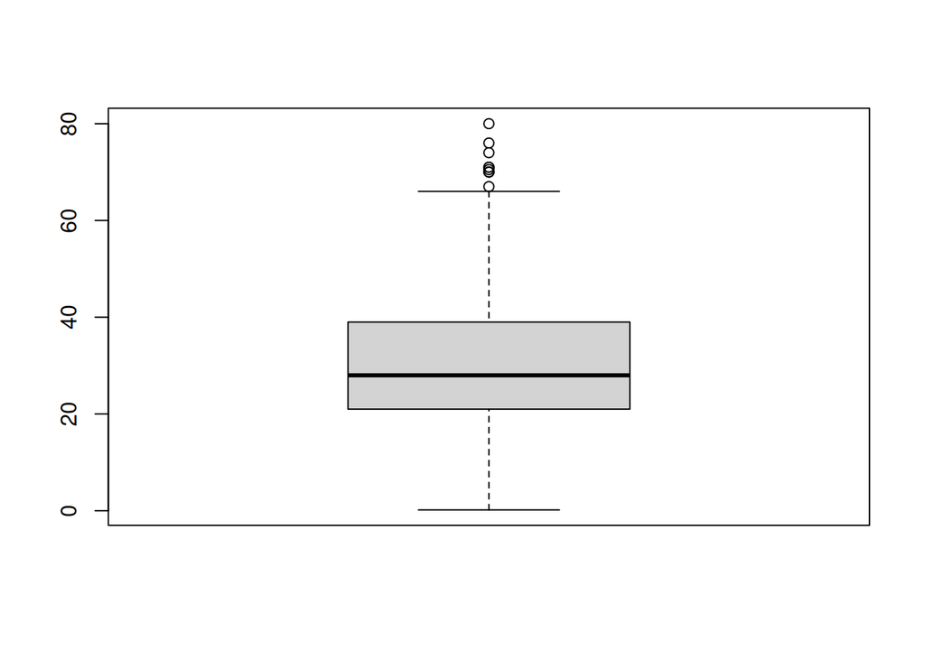

```r
boxplot(titanic$Age)
```

```r
mean(titanic$Age,na.rm = T)
```

```
## [1] 29.88114
```

```r
median(titanic$Age,na.rm = T)
```

```
## [1] 28
```

```r
titanic[is.na(titanic$Age),]$Age=median(titanic$Age,na.rm = T)
summary(titanic)
```

```
##      Pclass          Sex                 Age            SibSp
##  Min.   :1.000   Length:1309        Min.   : 0.17   Min.   :0.0000
##  1st Qu.:2.000   Class :character   1st Qu.:22.00   1st Qu.:0.0000
##  Median :3.000   Mode  :character   Median :28.00   Median :0.0000
##  Mean   :2.295                      Mean   :29.50   Mean   :0.4989
##  3rd Qu.:3.000                      3rd Qu.:35.00   3rd Qu.:1.0000
##  Max.   :3.000                      Max.   :80.00   Max.   :8.0000
##
##       Fare           Embarked             Parch          Survived
##  Min.   :  0.000   Length:1309        Min.   :0.000   Min.   :0.0000
##  1st Qu.:  7.896   Class :character   1st Qu.:0.000   1st Qu.:0.0000
##  Median : 14.454   Mode  :character   Median :0.000   Median :0.0000
##  Mean   : 33.295                      Mean   :0.385   Mean   :0.3838
##  3rd Qu.: 31.275                      3rd Qu.:0.000   3rd Qu.:1.0000
##  Max.   :512.329                      Max.   :9.000   Max.   :1.0000
##  NA's   :1                                            NA's   :418
```

```r
titanic=titanic[!is.na(titanic$Survived),]#delete all rows has survived don't have a value
titanic=titanic[!is.na(titanic$Embarked),]#replace value missed by the titanic=titanic[-c(62,830),]
str(titanic)
```

```
## 'data.frame':    891 obs. of  8 variables:
##  $ Pclass  : int  3 1 3 1 3 3 1 3 3 2 ...
##  $ Sex     : chr  "male" "female" "female" "female" ...
##  $ Age     : num  22 38 26 35 35 28 54 2 27 14 ...
##  $ SibSp   : int  1 1 0 1 0 0 0 3 0 1 ...
##  $ Fare    : num  7.25 71.28 7.92 53.1 8.05 ...
##  $ Embarked: chr  "S" "C" "S" "S" ...
##  $ Parch   : int  0 0 0 0 0 0 0 1 2 0 ...
##  $ Survived: int  0 1 1 1 0 0 0 0 1 1 ...
```

```r
sum(is.na(titanic)) #somme le nbre de valeur manquantes
```

```
## [1] 0
```

```r
colMeans(is.na(titanic)) #pourcentage de valeurs manquante dans chaque colonne
```

```
##   Pclass      Sex      Age    SibSp     Fare Embarked    Parch Survived
##        0        0        0        0        0        0        0        0
```

```r
library(MASS)
str(titanic)
```

```
## 'data.frame':    891 obs. of  8 variables:
##  $ Pclass  : int  3 1 3 1 3 3 1 3 3 2 ...
##  $ Sex     : chr  "male" "female" "female" "female" ...
##  $ Age     : num  22 38 26 35 35 28 54 2 27 14 ...
##  $ SibSp   : int  1 1 0 1 0 0 0 3 0 1 ...
##  $ Fare    : num  7.25 71.28 7.92 53.1 8.05 ...
##  $ Embarked: chr  "S" "C" "S" "S" ...
##  $ Parch   : int  0 0 0 0 0 0 0 1 2 0 ...
##  $ Survived: int  0 1 1 1 0 0 0 0 1 1 ...
```

```r
titanic$Survived=factor(titanic$Survived)
titanic$Pclass=factor(titanic$Pclass)
titanic$Sex=factor(titanic$Sex)
titanic$Embarked=factor(titanic$Embarked)
str(titanic)
```

```
## 'data.frame':    891 obs. of  8 variables:
##  $ Pclass  : Factor w/ 3 levels "1","2","3": 3 1 3 1 3 3 1 3 3 2 ...
##  $ Sex     : Factor w/ 2 levels "female","male": 2 1 1 1 2 2 2 2 1 1 ...
##  $ Age     : num  22 38 26 35 35 28 54 2 27 14 ...
##  $ SibSp   : int  1 1 0 1 0 0 0 3 0 1 ...
##  $ Fare    : num  7.25 71.28 7.92 53.1 8.05 ...
##  $ Embarked: Factor w/ 4 levels "","C","Q","S": 4 2 4 4 4 3 4 4 4 2 ...
##  $ Parch   : int  0 0 0 0 0 0 0 1 2 0 ...
##  $ Survived: Factor w/ 2 levels "0","1": 1 2 2 2 1 1 1 1 2 2 ...
```

Garder uniquement les variables qui nous sont utiles pour l’analyse. Notons que seul les variables ayant uniquement un porcentage vraimnent significatif seront traiter. La var Fare n’ayant pas un pourcentage de valeurs manquante ne sera pas traité a dessin

```r
library(dplyr)
str(titanic)
```

```
## 'data.frame':    891 obs. of  8 variables:
##  $ Pclass  : Factor w/ 3 levels "1","2","3": 3 1 3 1 3 3 1 3 3 2 ...
##  $ Sex     : Factor w/ 2 levels "female","male": 2 1 1 1 2 2 2 2 1 1 ...
##  $ Age     : num  22 38 26 35 35 28 54 2 27 14 ...
##  $ SibSp   : int  1 1 0 1 0 0 0 3 0 1 ...
##  $ Fare    : num  7.25 71.28 7.92 53.1 8.05 ...
##  $ Embarked: Factor w/ 4 levels "","C","Q","S": 4 2 4 4 4 3 4 4 4 2 ...
##  $ Parch   : int  0 0 0 0 0 0 0 1 2 0 ...
##  $ Survived: Factor w/ 2 levels "0","1": 1 2 2 2 1 1 1 1 2 2 ...
```

```r
sum(is.na(titanic)) #somme le nbre de valeur manquantes
```

```
## [1] 0
```

```r
colMeans(is.na(titanic)) #pourcentage de valeurs manquante dans chaque colonne
```

```
##   Pclass      Sex      Age    SibSp     Fare Embarked    Parch Survived
##        0        0        0        0        0        0        0        0
```

```r
summary(titanic)
```

```
##  Pclass      Sex           Age            SibSp            Fare        Embarked
##  1:216   female:314   Min.   : 0.42   Min.   :0.000   Min.   :  0.00    :  2
##  2:184   male  :577   1st Qu.:22.00   1st Qu.:0.000   1st Qu.:  7.91   C:168
##  3:491                Median :28.00   Median :0.000   Median : 14.45   Q: 77
##                       Mean   :29.36   Mean   :0.523   Mean   : 32.20   S:644
##                       3rd Qu.:35.00   3rd Qu.:1.000   3rd Qu.: 31.00
##                       Max.   :80.00   Max.   :8.000   Max.   :512.33
##      Parch        Survived
##  Min.   :0.0000   0:549
##  1st Qu.:0.0000   1:342
##  Median :0.0000
##  Mean   :0.3816
##  3rd Qu.:0.0000
##  Max.   :6.0000
```

Gerons la variable Embarked

```r
#titanic$Embarked= fct_recode(titanic$Embarked, "NA's"="")
str(titanic)
```

```
## 'data.frame':    891 obs. of  8 variables:
##  $ Pclass  : Factor w/ 3 levels "1","2","3": 3 1 3 1 3 3 1 3 3 2 ...
##  $ Sex     : Factor w/ 2 levels "female","male": 2 1 1 1 2 2 2 2 1 1 ...
##  $ Age     : num  22 38 26 35 35 28 54 2 27 14 ...
##  $ SibSp   : int  1 1 0 1 0 0 0 3 0 1 ...
##  $ Fare    : num  7.25 71.28 7.92 53.1 8.05 ...
##  $ Embarked: Factor w/ 4 levels "","C","Q","S": 4 2 4 4 4 3 4 4 4 2 ...
##  $ Parch   : int  0 0 0 0 0 0 0 1 2 0 ...
##  $ Survived: Factor w/ 2 levels "0","1": 1 2 2 2 1 1 1 1 2 2 ...
```

```r
filter(titanic, Embarked == "")
```

```
##   Pclass    Sex Age SibSp Fare Embarked Parch Survived
## 1      1 female  38     0   80              0        1
## 2      1 female  62     0   80              0        1
```

```r
which(titanic$Embarked == "")
```

```
## [1]  62 830
```

```r
titanic= titanic[-c(62,830), ]
summary(titanic)
```

```
##  Pclass      Sex           Age            SibSp             Fare
##  1:214   female:312   Min.   : 0.42   Min.   :0.0000   Min.   :  0.000
##  2:184   male  :577   1st Qu.:22.00   1st Qu.:0.0000   1st Qu.:  7.896
##  3:491                Median :28.00   Median :0.0000   Median : 14.454
##                       Mean   :29.32   Mean   :0.5242   Mean   : 32.097
##                       3rd Qu.:35.00   3rd Qu.:1.0000   3rd Qu.: 31.000
##                       Max.   :80.00   Max.   :8.0000   Max.   :512.329
##  Embarked     Parch        Survived
##   :  0    Min.   :0.0000   0:549
##  C:168    1st Qu.:0.0000   1:340
##  Q: 77    Median :0.0000
##  S:644    Mean   :0.3825
##           3rd Qu.:0.0000
##           Max.   :6.0000
```

```r
str(titanic)
```

```
## 'data.frame':    889 obs. of  8 variables:
##  $ Pclass  : Factor w/ 3 levels "1","2","3": 3 1 3 1 3 3 1 3 3 2 ...
##  $ Sex     : Factor w/ 2 levels "female","male": 2 1 1 1 2 2 2 2 1 1 ...
##  $ Age     : num  22 38 26 35 35 28 54 2 27 14 ...
##  $ SibSp   : int  1 1 0 1 0 0 0 3 0 1 ...
##  $ Fare    : num  7.25 71.28 7.92 53.1 8.05 ...
##  $ Embarked: Factor w/ 4 levels "","C","Q","S": 4 2 4 4 4 3 4 4 4 2 ...
##  $ Parch   : int  0 0 0 0 0 0 0 1 2 0 ...
##  $ Survived: Factor w/ 2 levels "0","1": 1 2 2 2 1 1 1 1 2 2 ...
```

Voilà que le cleaning data est finish

3)Nous pouvons a present si l’on veux passer à la data visualisation

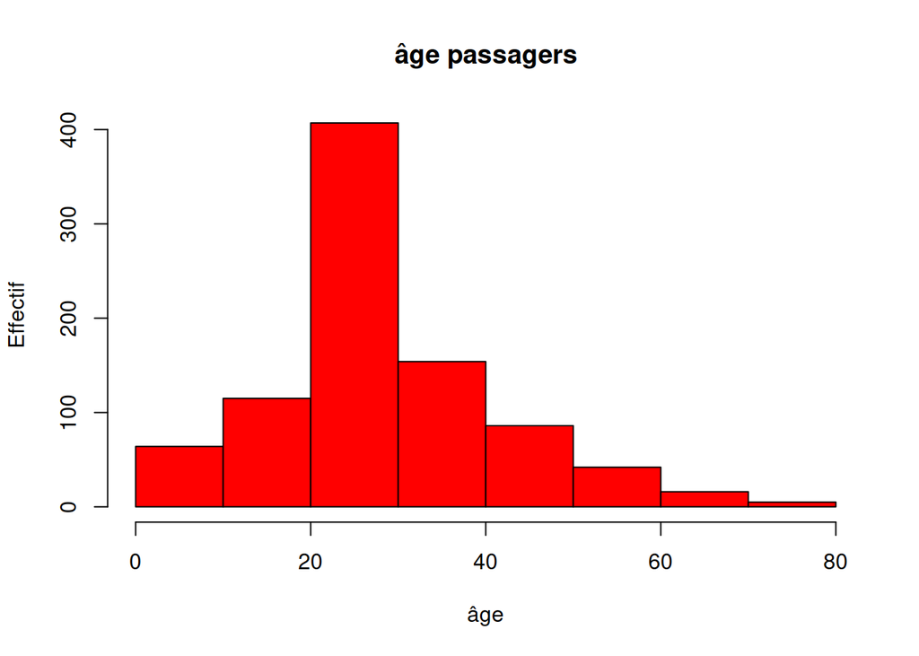

```r
hist(titanic$Age, main = "âge passagers",
  xlab = "âge", ylab = "Effectif",col = "red")
```

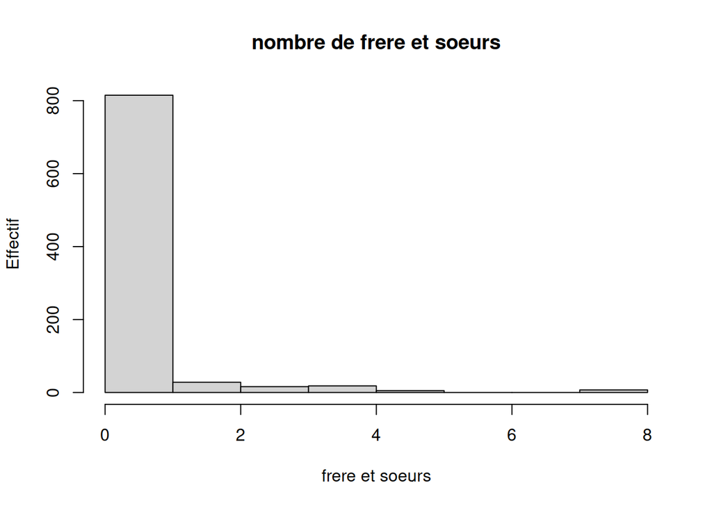

```r
hist(titanic$SibSp, main = "nombre de frere et soeurs",
  xlab = "frere et soeurs", ylab = "Effectif")
```

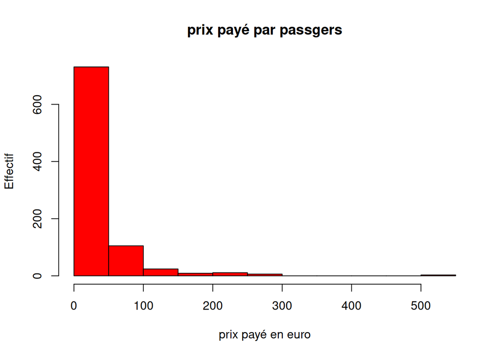

```r
hist(titanic$Fare, main = "prix payé par passgers",
  xlab = "prix payé en euro", ylab = "Effectif",col = "red")
```

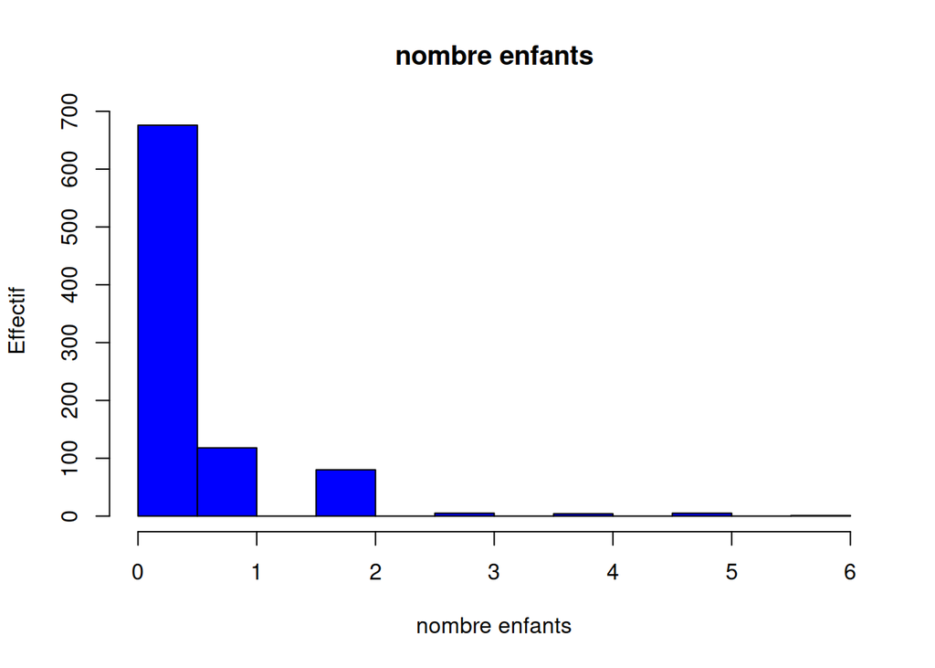

```r
hist(titanic$Parch, main = "nombre enfants",
  xlab = "nombre enfants", ylab = "Effectif",col = "blue")
```

#var quali

```r
table(titanic$Sex)
```

```
##
## female   male
##    312    577
```

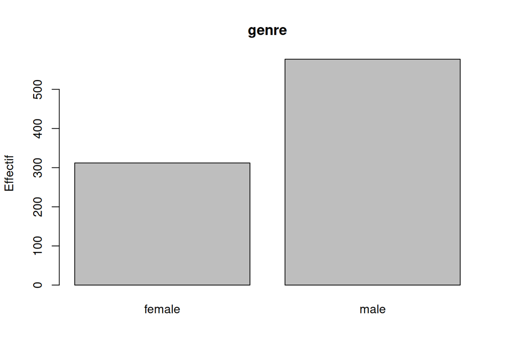

```r
plot(titanic$Sex, main = "genre", ylab = "Effectif") #plus facile a interpreter en quali
```

```r
table(titanic$Pclass)
```

```
##
##   1   2   3
## 214 184 491
```

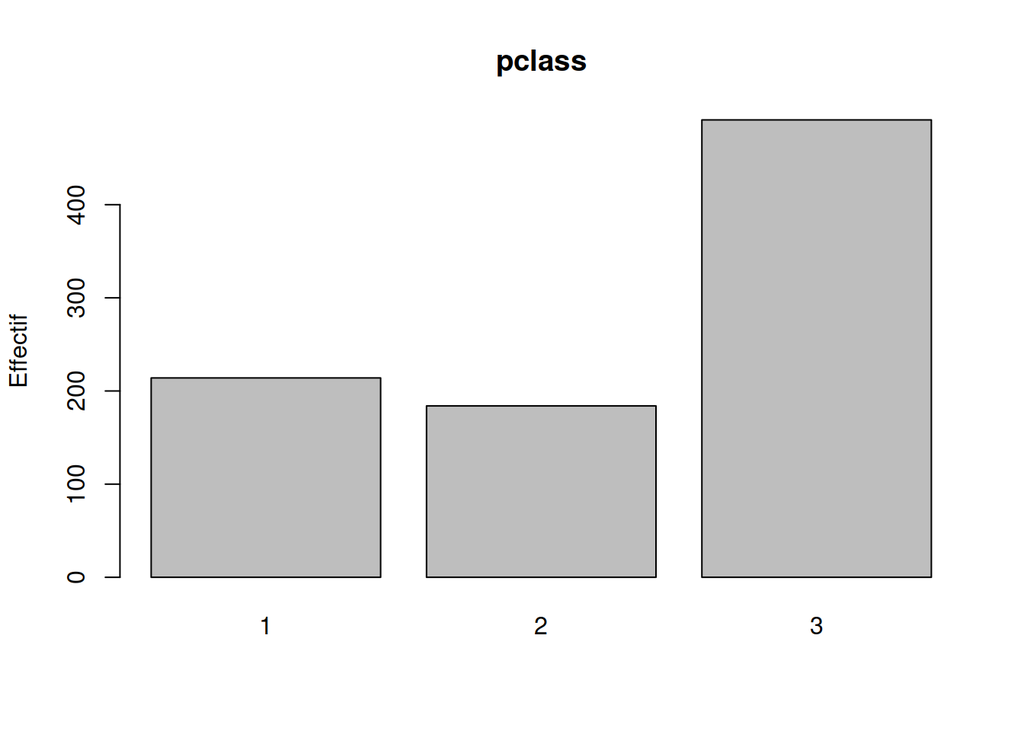

```r
plot(titanic$Pclass, main = "pclass", ylab = "Effectif") #plus facile a interpreter en quali
```

```r
table(titanic$Embarked)
```

```
##
##       C   Q   S
##   0 168  77 644
```

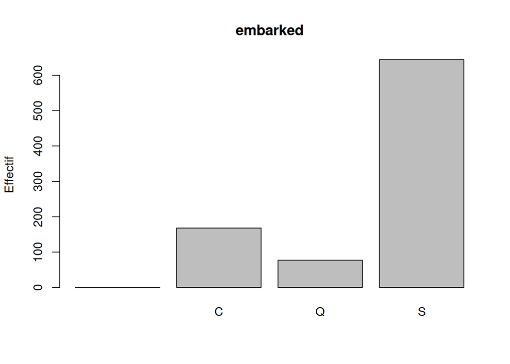

```r
plot(titanic$Embarked, main = "embarked", ylab = "Effectif") #plus facile a interpreter en quali
```

```r
table(titanic$Survived)
```

```
##
##   0   1
## 549 340
```

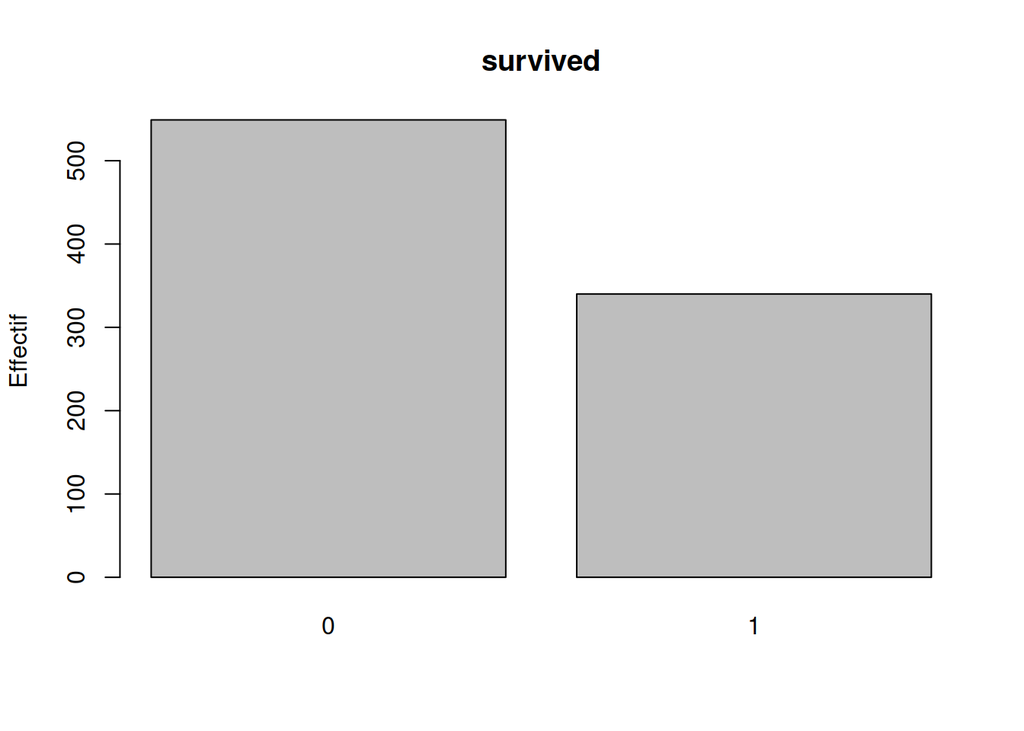

```r
plot(titanic$Survived, main = "survived", ylab = "Effectif") #plus facile a interpreter en quali
```

#bivarié

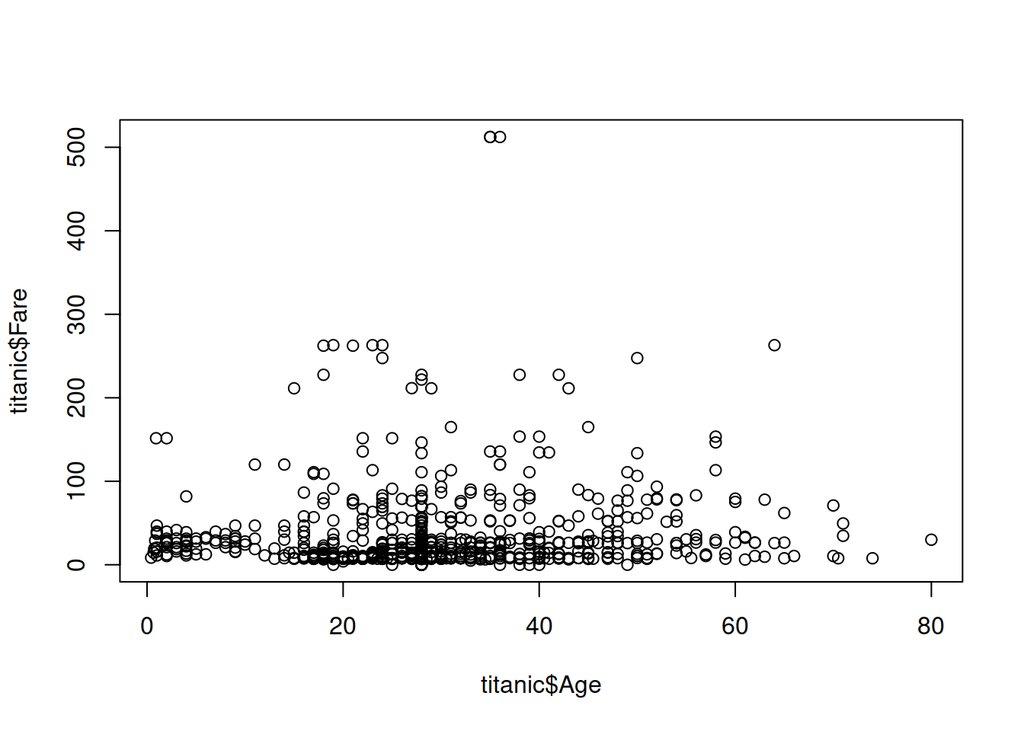

```r
plot(titanic$Age, titanic$Fare)
```

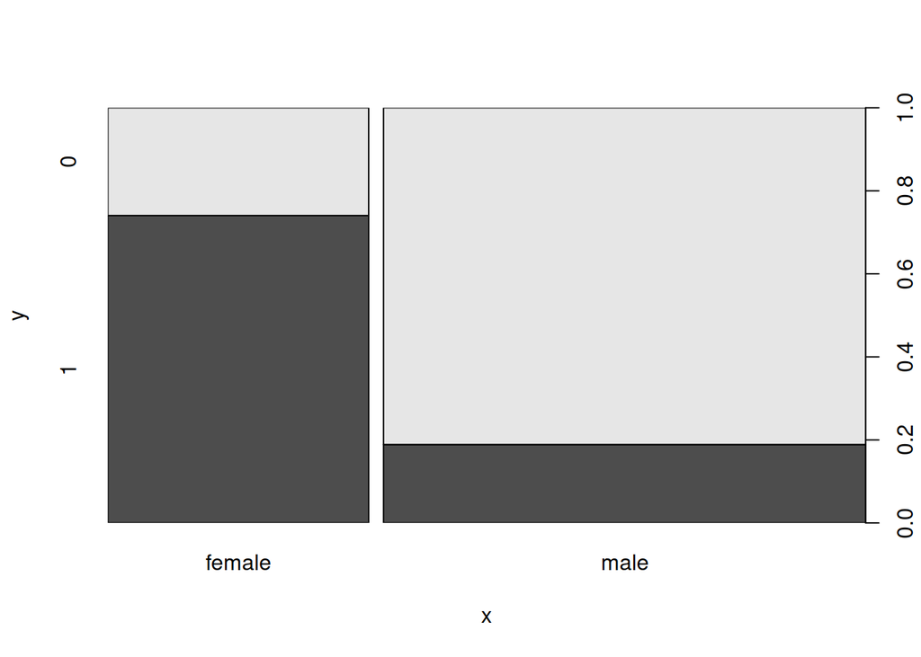

```r
plot(titanic$Sex, titanic$Survived)
```

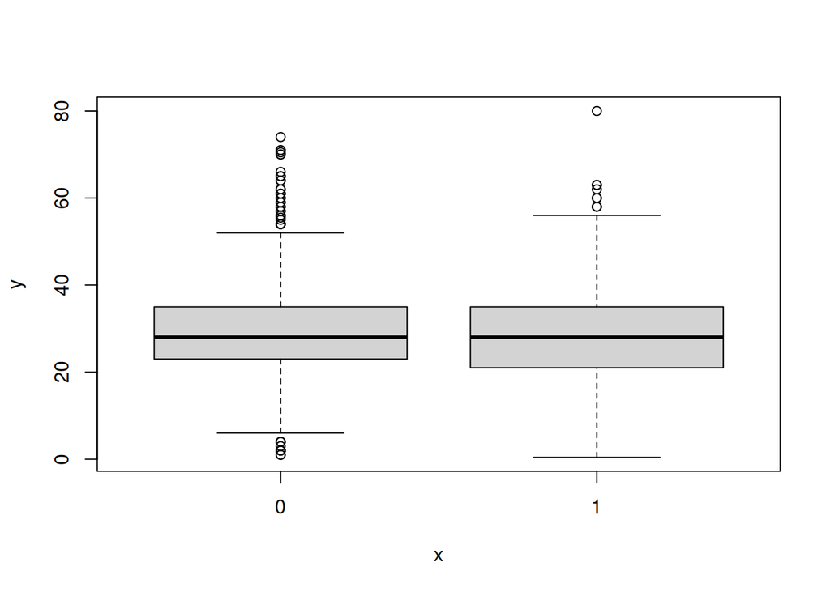

```r
plot(titanic$Survived,titanic$Age )
```

*Ainsi de suite……………………………………………………..*

4)modelisation des données syndage des données

```r
set.seed(1000)
tirage=sample(2,nrow(titanic),replace = TRUE,prob = c(0.8,0.2))
titTrain=titanic[tirage==1,]
titTest=titanic[tirage==2,]
```

nous entrainerons le modèle avec la bd titTrain

```r
library(caret)
#titrain=trainControl(method = "cv",number = 10,savePredictions = T)
model1=glm(Survived~.,family = binomial(),data = titTrain)
#model11=train(Survived~., family=binomial(), methods="glm",data = titant1, trainControl=titrain)
summary(model1)
```

```
##
## Call:
## glm(formula = Survived ~ ., family = binomial(), data = titTrain)
##
## Deviance Residuals:
##     Min       1Q   Median       3Q      Max
## -2.5822  -0.5996  -0.4118   0.6227   2.4629
##
## Coefficients:
##              Estimate Std. Error z value Pr(>|z|)
## (Intercept)  4.147532   0.538073   7.708 1.28e-14 ***
## Pclass2     -0.745244   0.337133  -2.211   0.0271 *
## Pclass3     -2.174654   0.340626  -6.384 1.72e-10 ***
## Sexmale     -2.711133   0.225905 -12.001  < 2e-16 ***
## Age         -0.036623   0.008623  -4.247 2.16e-05 ***
## SibSp       -0.276330   0.126532  -2.184   0.0290 *
## Fare         0.001849   0.003227   0.573   0.5665
## EmbarkedQ   -0.218349   0.415826  -0.525   0.5995
## EmbarkedS   -0.648612   0.267885  -2.421   0.0155 *
## Parch       -0.066040   0.129603  -0.510   0.6104
## ---
## Signif. codes:  0 '***' 0.001 '**' 0.01 '*' 0.05 '.' 0.1 ' ' 1
##
## (Dispersion parameter for binomial family taken to be 1)
##
##     Null deviance: 956.65  on 718  degrees of freedom
## Residual deviance: 628.25  on 709  degrees of freedom
## AIC: 648.25
##
## Number of Fisher Scoring iterations: 5
```

linearité des var signif

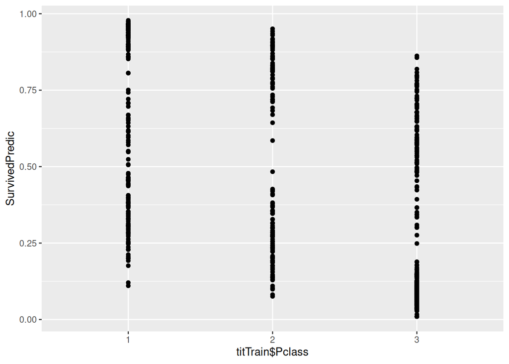

```r
SurvivedPredic=predict.glm(model1,type = "response")
par(mfrow=c(3,3))
ggplot(titTrain, aes(x=titTrain$Pclass,y=SurvivedPredic))+geom_point()+geom_smooth(method = "glm", method.args=list(family ="binomial" ))
```

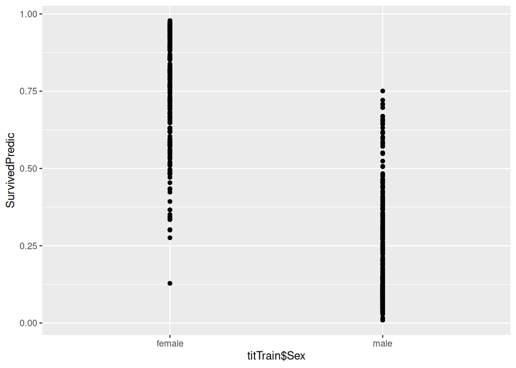

```r
ggplot(titTrain, aes(x=titTrain$Sex,y=SurvivedPredic))+geom_point()+geom_smooth(method = "glm", method.args=list(family ="binomial" ))
```

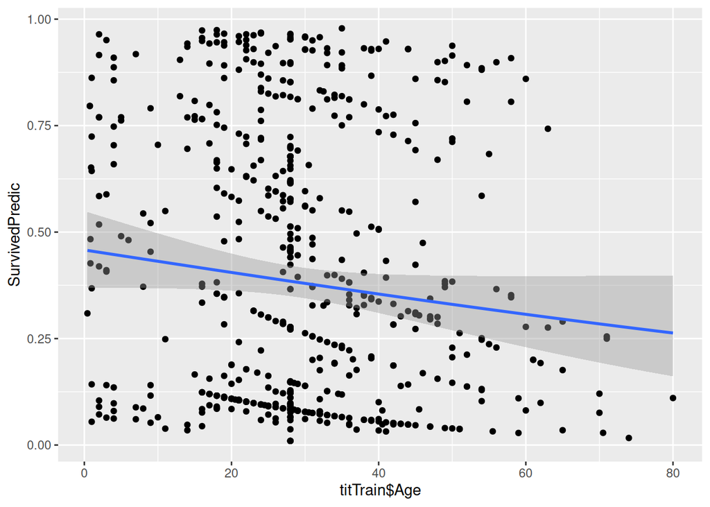

```r
ggplot(titTrain, aes(x=titTrain$Age,y=SurvivedPredic))+geom_point()+geom_smooth(method = "glm", method.args=list(family ="binomial" ))
```

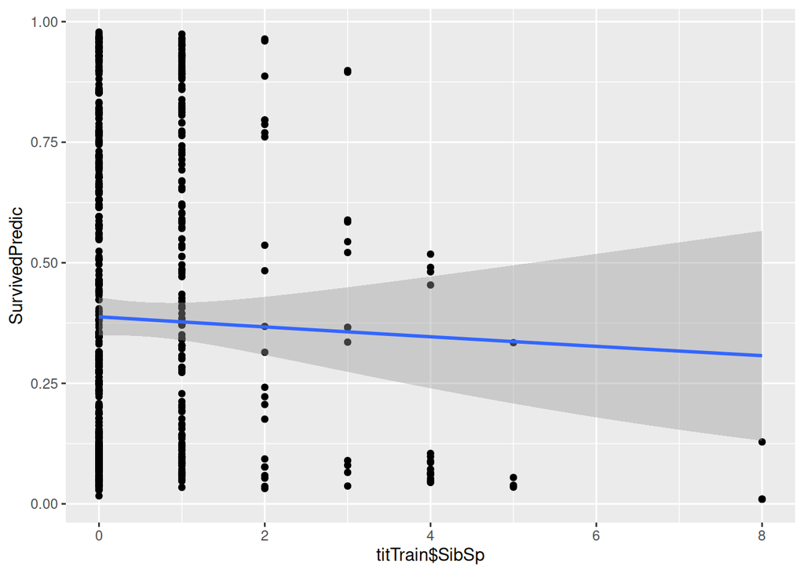

```r
ggplot(titTrain, aes(x=titTrain$SibSp,y=SurvivedPredic))+geom_point()+geom_smooth(method = "glm", method.args=list(family ="binomial" ))
```

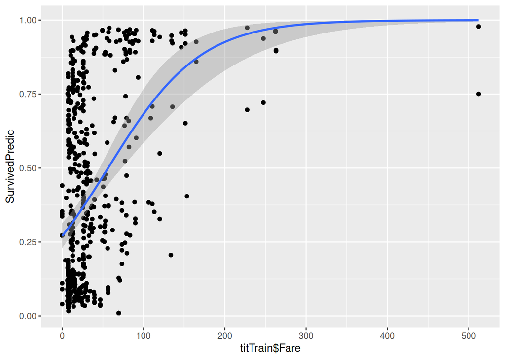

```r
ggplot(titTrain, aes(x=titTrain$Fare,y=SurvivedPredic))+geom_point()+geom_smooth(method = "glm", method.args=list(family ="binomial" ))
```

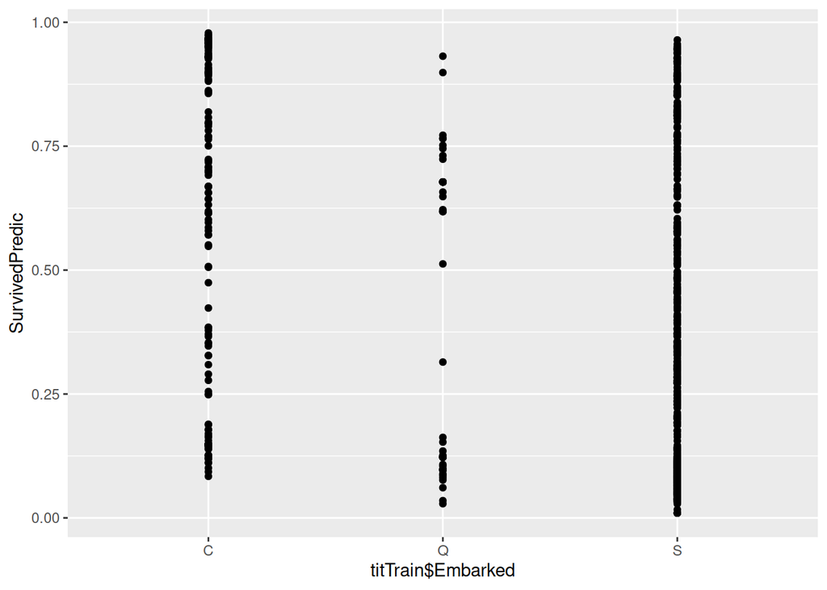

```r
ggplot(titTrain, aes(x=titTrain$Embarked,y=SurvivedPredic))+geom_point()+geom_smooth(method = "glm", method.args=list(family ="binomial" ))
```

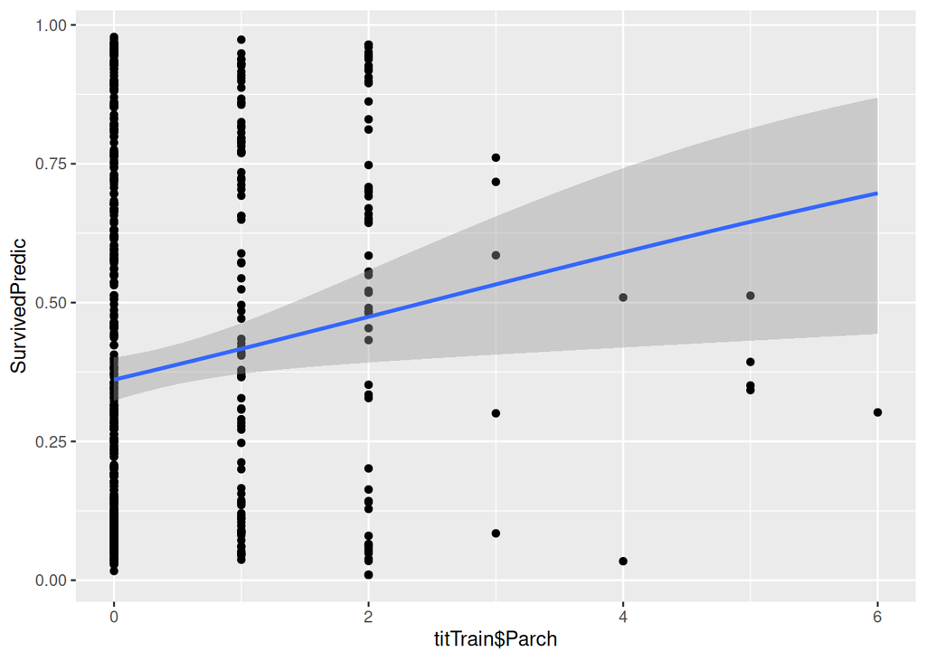

```r
ggplot(titTrain, aes(x=titTrain$Parch,y=SurvivedPredic))+geom_point()+geom_smooth(method = "glm", method.args=list(family ="binomial" ))
```